# R Notebook

# Control Data Analysis

Who wins, and what happens when we just look at situations where all plots are combined?

`r`r library(dplyr)

`r`r library(tidyr)

`r`r library(knitr) library(ggplot2)

`r`r library(testthat)

`r`r # Cover data (wide format) cover <- read.csv(../data/comdata_wideformat.csv, header = TRUE, stringsAsFactors = FALSE) group_percents = cover[,12:23] cover = cover[,-(12:23)] # Treatment labels and group structure trtlabels <- read.csv(../data/trtlabels.csv, header = TRUE, stringsAsFactors = FALSE) # Biomass data biomass <- read.csv(../data/biomass_all.csv, header = TRUE, stringsAsFactors = FALSE) # Other treatment labels (checking for redundancy) checklabels <- read.csv(../data/plot_ids.csv, header = TRUE, stringsAsFactors = FALSE) checklabels$Sp.comp <- gsub(\ \, \\, checklabels$Sp.comp) # Species treatments waps.specs <- read.csv(../data/WAPSspecies.csv, header = TRUE, stringsAsFactors = FALSE) # Functional group percent composition funcgroups <- read.csv(../data/func_group_percents.csv, header = TRUE, stringsAsFactors = FALSE) funcgroups = funcgroups %>% select(-X)

`r`r NWA = funcgroups %>% filter(sp.trt == +WAPS+annuals) NWA[,4:ncol(NWA)] = vegan::decostand(NWA[,4:ncol(NWA)], method = )

# Visualizing differences in functional group cover:

Question of whether or not to normalize cover before conducting this analysis

Proportionally, we see that natives are a much bigger fraction ofoverall cover in the “dry” treatment - persistence of perennials under dry conditions where everything else suffers. Curiously, they seem to do worst in “wet” conditions. I’d be curious to see what happens when they are given temporal priority - e.g. a more standard restoration setting.

`r`r NWA_long = gather(NWA, key = , value = , -c(plot, year, sp.trt)) NWA_long = left_join(NWA_long, trtlabels, by = ) NWA_long %>% filter(clip == & fert == & h2o != -2nd) %>% filter(h2o == ) %>% ggplot(aes(x = year, y = cover, color = class)) + geom_point() + stat_smooth(se = FALSE) + ylim(0,1) + ggtitle(H2O)

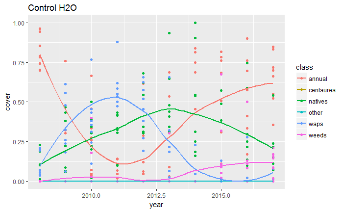

`r`r NWA_long %>% filter(clip == & fert == & h2o != -2nd) %>% filter(h2o == ) %>% ggplot(aes(x = year, y = cover, color = class)) + geom_point() + stat_smooth(se = FALSE) + ylim(0,1)+ ggtitle(H2O)

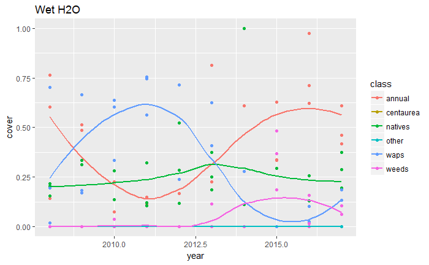

`r`r NWA_long %>% filter(clip == & fert == & h2o != -2nd) %>% filter(h2o == ) %>% ggplot(aes(x = year, y = cover, color = class)) + geom_point() + stat_smooth(se = FALSE) + ylim(0,1)+ ggtitle(H2O)

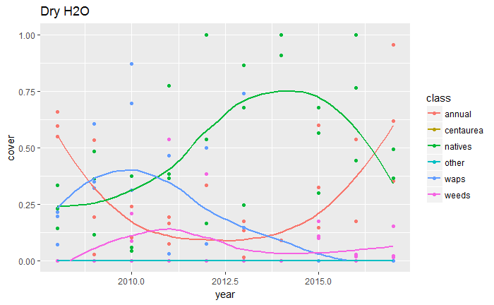

`r`r NWA_long %>% filter(clip == & fert == & h2o != -2nd) %>% filter(h2o == wet) %>% ggplot(aes(x = year, y = cover, color = class)) + geom_point() + stat_smooth(se = FALSE) + ylim(0,1)+ ggtitle(Wet H2O)

[figure not shown]

# Visualizing this with NMDS

`r`r library(vegan)

`r`r comp.attr <- cover[,1:11] comp.cover <- cover[,12:ncol(cover)] selected.trts <-c(+WAPS+annuals) selected.clips <- c() selected.fert <- c() selected.water <- c(, , , ) ord.mat <- comp.cover[comp.attr$h2o %in% selected.water & comp.attr$sp.trt %in% selected.trts & comp.attr$clip %in% selected.clips& comp.attr$fertilization %in% selected.fert,] ord.att <- comp.attr[comp.attr$h2o %in% selected.water & comp.attr$sp.trt %in% selected.trts & comp.attr$clip %in% selected.clips & comp.attr$fertilization %in% selected.fert,] expect_true(nrow(ord.att) == nrow(ord.mat)) # A number of rows have no recorded live plants (not s) ord.att <- ord.att[rowSums(ord.mat) != 0, ] ord.mat <- ord.mat[rowSums(ord.mat) != 0, ] ord.mat <- decostand(ord.mat, method = ) distmat <- vegdist(ord.mat, method = ) WAPS.mds <- metaMDS(distmat, try = 5, trymax = 50, trace = F) MDS_xy <- bind_cols(data.frame(ord.att), data.frame(X = WAPS.mds$points[,1], Y = WAPS.mds$points[,2])) #WAPS.pca <- prcomp(ord.mat) #PCA_xy <- cbind(data.frame(ord.att), data.frame(X = WAPS.pca$x[,1], Y = WAPS.pca$x[,2])) WAPS.mds$stress

```
[1] 0.1906737
```

`r`r library(ggplot2) ggplot(MDS_xy, aes(X1, Y, color = h2o)) + geom_point() + theme_bw() + facet_wrap(~year)

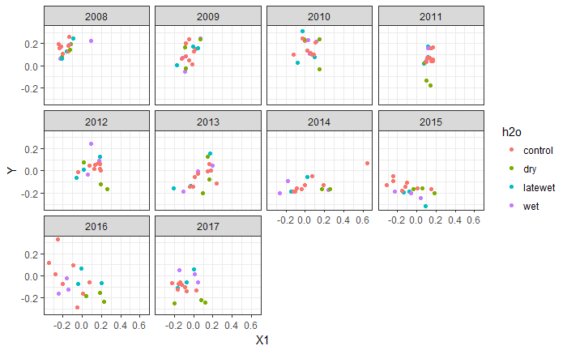

`r`r adonis(distmat ~ h2o * as.factor(year), data = ord.att)

```
Call:
adonis(formula = distmat ~ h2o * as.factor(year), data = ord.att)

Permutation: free
Number of permutations: 999

Terms added sequentially (first to last)

                     Df SumsOfSqs MeanSqs F.Model      R2 Pr(>F)
h2o                   3     1.762 0.58728  3.9531 0.04014  0.001 ***
as.factor(year)       9    17.862 1.98462 13.3587 0.40698  0.001 ***
h2o:as.factor(year)  27     4.951 0.18337  1.2343 0.11281  0.041 *
Residuals           130    19.313 0.14856         0.44006
Total               169    43.888                 1.00000
---
Signif. codes:  0 â€˜***â€™ 0.001 â€˜**â€™ 0.01 â€˜*â€™ 0.05 â€˜.â€™ 0.1 â€˜ â€™ 1
```

`r`r m = betadisper(distmat, paste(ord.att$h2o, ord.att$year)) plot(m)

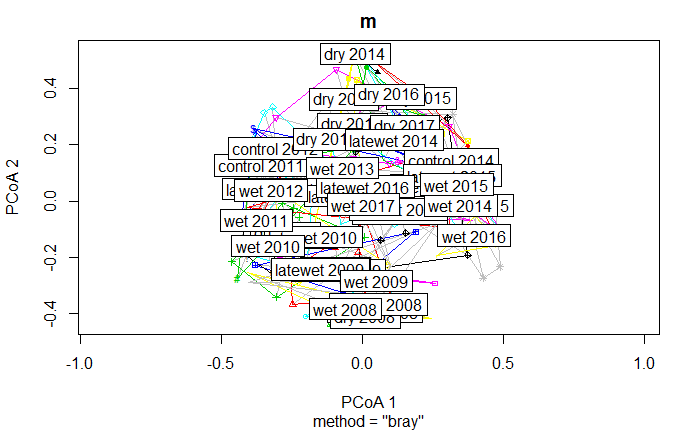

`r`r TukeyHSD(m)

[output not shown]

[output cut: 203 more lines]

[output not shown]

`r`r m2 = capscale(distmat ~ h2o + as.factor(year), data = ord.att) unique(ord.att$plot)

```
 [1]  25  80 124 198 227 272 300 317 369 405 441 478 492 560 562 661 744
```

`r`r anova(m2)

```
Permutation test for capscale under reduced model
Permutation: free
Number of permutations: 999

Model: capscale(formula = distmat ~ h2o + as.factor(year), data = ord.att)
          Df SumOfSqs      F Pr(>F)
Model     12   20.561 7.5898  0.001 ***
Residual 157   35.443
---
Signif. codes:  0 â€˜***â€™ 0.001 â€˜**â€™ 0.01 â€˜*â€™ 0.05 â€˜.â€™ 0.1 â€˜ â€™ 1
```

`r`r step(m2)

```
Start:  AIC=631.54
distmat ~ h2o + as.factor(year)

                  Df    AIC
<none>               631.54
- h2o              3 634.81
- as.factor(year)  9 685.18
Call: capscale(formula = distmat ~ h2o + as.factor(year), data = ord.att)

               Inertia Proportion Rank
Total          43.8877     1.0000
Constrained    20.5607     0.4685   12
Unconstrained  35.4426     0.8076   61
Imaginary     -12.1156    -0.2761  106
Inertia is squared Bray distance

Eigenvalues for constrained axes:
 CAP1  CAP2  CAP3  CAP4  CAP5  CAP6  CAP7  CAP8  CAP9 CAP10 CAP11 CAP12
7.931 6.326 1.956 1.513 1.098 0.618 0.481 0.206 0.189 0.104 0.094 0.044

Eigenvalues for unconstrained axes:
 MDS1  MDS2  MDS3  MDS4  MDS5  MDS6  MDS7  MDS8
7.075 4.460 2.591 2.222 2.062 1.925 1.643 1.344
(Showed only 8 of all 61 unconstrained eigenvalues)
```

`r`r plot(m2)

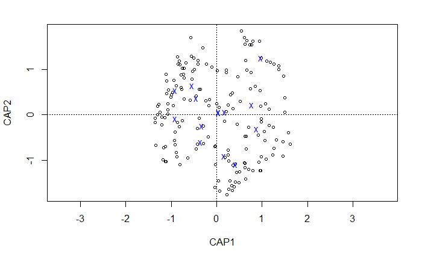

[output not shown]